# Mid-Term Summary Paper: Examining the Relationship Between Demographics, Admission Types, and Clinical Outcomes in New York Inpatients (Niagara County)

Team 2: Simintaj Salehpour, Madeline Bumpus, Nazish Atta, Divya Mistry

October 29, 2025

# 1 Introduction

Our team chose to examine differences in **hospital length of stay (LOS)** across **insurance types** because it highlights an important intersection between healthcare access, cost, and patient outcomes. The relationship between insurance coverage and hospital utilization is central to understanding disparities in care delivery and efficiency within the U.S. healthcare system. We were particularly interested in comparing **Medicare**, which primarily serves older adults, and **Private Insurance**, which often provides broader access to care, to see how coverage type influences hospital resource use. Members of our team who have personally dealt with **Medicaid** and have seen firsthand how insurance status can impact the quality, timing, and length of medical care also find personal significance in this topic. We sought to better understand how insurance differences translate into quantifiable healthcare outcomes by combining our personal viewpoints with data-driven evidence through the analysis of actual hospital discharge data.

# 2 Data Description

## 2.1 Datasets used

This analysis uses data from the **New York State Department of Health (NYSDOH) Statewide Planning and Research Cooperative System (SPARCS)**, specifically the *Hospital Inpatient Discharges (SPARCS De-Identified)* dataset for **Niagara County, 2012**. The dataset includes detailed records of all hospital discharges statewide, with variables describing patient demographics, diagnoses, procedures, hospital facility characteristics, insurance/payment type, admission type, and clinical outcomes. Each row represents one patient discharge, allowing for analysis of trends in hospital length of stay, cost, and patient mix. The full dataset contains over **2 million records** across New York State; for this project, a subset of approximately **21,000 discharges from Niagara County** was used to maintain manageability and statistical power. This dataset is publicly available through the **NY Open Data Portal** and is widely used in healthcare policy, public health, and data science research.

## 2.2 Limitations

While comprehensive, the SPARCS dataset has several limitations:

- **Socioeconomic data**: Includes insurance type but lacks indicators such as income or education.
- **Clinical detail**: Limited measures of illness severity or comorbidities.
- **Temporal relevance**: Data from 2012; may not reflect post–Affordable Care Act effects.
- **Post-discharge outcomes**: No readmissions or long-term outcomes.
- **Behavioral factors**: Missing data on lifestyle and health behaviors.

Additional data on patient severity, comorbidities, or post-discharge outcomes would allow for more nuanced analyses and better control for confounding factors.

## 2.3 Variable glossary (required for reproducibility)

Our team chose to examine differences in hospital length of stay across insurance types because it highlights an important intersection between healthcare access, cost, and patient outcomes.The relationship between insurance coverage and hospital utilization is central to understanding disparities in care delivery and efficiency within the U.S. healthcare system. We were particularly interested in comparing Medicare, which primarily serves older adults, and Private Insurance, which often provides broader access to care, to see how coverage type influences hospital resource use. Members of our team who have personally dealt with Medicaid and have seen firsthand how insurance status can impact the quality, timing, and length of medical care also find personal significance in this topic. We sought to better understand how insurance differences translate into quantifiable healthcare outcomes by combining our personal viewpoints with data-driven evidence through the analysis of actual hospital discharge data.

| **Field Name** | **Type** | **Description** |
| --- | --- | --- |
| hospital_service_area | Text | — |
| hospital_county | Text | — |
| operating_certificate_number | Text | — |
| facility_id | Number | — |
| facility_name | Text | — |
| age_group | Text | — |
| zip_code_3_digits | Text | 3-digit ZIP code. |
| gender | Text | (M) Male, (F) Female, (U) Unknown. |
| race | Text | Black/African American, Multi, Other Race, Unknown, White. “Other” includes Native Americans and Asian/Pacific Islanders. |
| ethnicity | Text | Spanish/Hispanic Origin, Not of Spanish/Hispanic Origin, Multi, Unknown. |
| length_of_stay | Text | (Discharge − Admission) + 1; LOS ≥120 coded as 120+. |
| type_of_admission | Text | Elective, Emergency, Newborn, Not Available, Trauma, Urgent. |
| patient_disposition | Text | Discharge destination/status. |
| discharge_year | Text | Year (CCYY) of discharge. |
| ccs_diagnosis_code | Text | AHRQ CCS Diagnosis Code. |
| ccs_diagnosis_description | Text | AHRQ CCS Diagnosis Description. |
| ccs_procedure_code | Text | AHRQ CCS Procedure Code. |
| ccs_procedure_description | Text | AHRQ CCS Procedure Description. |
| apr_drg_code | Text | APR-DRG Code. |
| apr_drg_description | Text | APR-DRG Description (v28). |
| apr_mdc_code | Text | APR Major Diagnostic Category (MDC) Code. |
| apr_mdc_description | Text | APR Major Diagnostic Category Description. |
| apr_severity_of_illness_code | Text | 1–4 (Minor to Extreme). |
| apr_severity_of_illness_description | Text | Minor(1), Moderate(2), Major(3), Extreme(4). |
| apr_risk_of_mortality | Text | 1–4 (Minor to Extreme). |
| apr_medical_surgical_description | Text | Medical, Surgical, or Not Applicable. |
| source_of_payment_1 | Text | Primary payment type. |
| source_of_payment_2 | Text | Secondary payment type. |
| source_of_payment_3 | Text | Tertiary payment type. |
| birth_weight | Text | Neonate weight (grams, rounded to 100g). |

```r
# Load CSV file
data <- read.csv("Hospital_Inpatient_Discharges.csv")

#Clean column names to avoid backticks

names(data) <- make.names(names(data))

cat("Dataset dimensions: Rows:", nrow(data), "Columns:", ncol(data), "\n")
```

```
## Dataset dimensions: Rows: 21075 Columns: 34
```

```r
#glimpse(data)
```

# 3 Exploratory Data Analysis (EDA) (Overview of Analytical Framework)

To evaluate the SMART questions, we used a **quantitative, inferential statistics** approach. The SPARCS 2012 Niagara County subset contained **21,075 records × 34 variables**.

- Check missing data
- Remove duplicate rows

## 3.1 Missing data

- Report missingness by variable: We check if there is a missing value or not. For each column check the missing value.

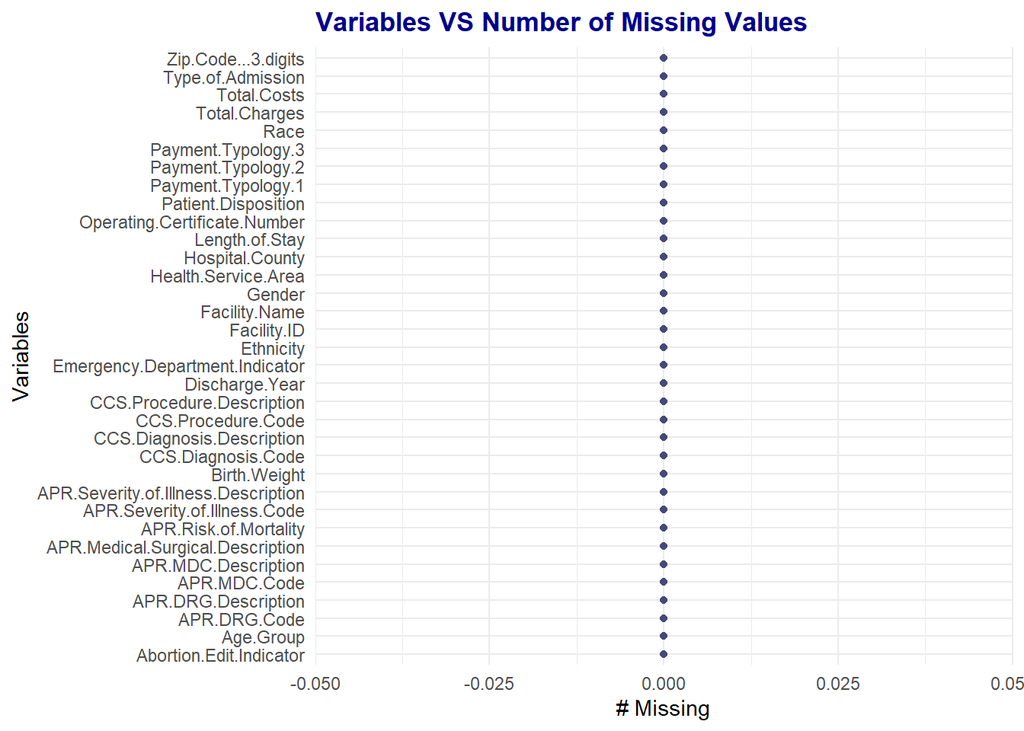

```r
# --- 1. Summary of missing values ---
missing_summary <- data %>% summarise(across(everything(), ~sum(is.na(.)))) %>%
  pivot_longer(everything(), names_to = "column(variable)", values_to = "n_missing") %>% arrange(desc(n_missing))

#missing_summary

# --- 2. Visualize missingness per column ---
gg_miss_var(data) + labs(title = "Variables VS Number of Missing Values") +
  theme( plot.title = element_text(face = "bold", color = "darkblue"))
```

```r
# --- 3. Check if there are any missing values ---
clean_data <- data
if(any(is.na(data))) {

  cat("Missing values detected!\n")
  total_missing <- sum(is.na(data))
  total_cells <- nrow(data) * ncol(data)

  # Remove rows if missing values are few (<5% of total data)
  if(total_missing / total_cells < 0.05) {
    clean_data <- na.omit(data)
    cat("Rows with missing values removed.\n")
  }
  else {
    # Impute numeric columns with median
    for(col in names(clean_data)) {
      if(is.numeric(clean_data[[col]])) {          # Check if the column is numeric
          clean_data[[col]][is.na(clean_data[[col]])] <- median(clean_data[[col]], na.rm = TRUE)
      }
    }
    cat("Missing values in numeric columns replaced with median.\n")
  }

} else {
  cat("No missing values detected. Dataset is clean.\n")
}
```

```
## No missing values detected. Dataset is clean.
```

## 3.2 Remove Duplicates

- Report Duplicates by row: Check to remove duplicates:

```r
dup_count <- sum(duplicated(clean_data))
cat("Number of duplicate rows:", dup_count, "\n")
```

```
## Number of duplicate rows: 4
```

```r
# Remove duplicates
clean_data <- clean_data %>% distinct()
```

# 4 SMART Questions

The team developed the following **SMART research questions** based on data availability, clinical reasoning, and literature review. These focus on measurable outcomes—length of stay and costs—to analyze healthcare disparities.

1. **Did Medicare patients have, on average, longer hospital stays than Private Insurance patients in 2012?**
- Rationale: Medicare serves older adults with more complex needs.
2. **Were Medicaid patients’ total hospital costs higher than those with Private Insurance in 2012?**
- Rationale: Medicaid patients may face barriers to preventive care.
3. **Did elderly patients (70+) stay longer than patients aged 30–49 in 2012?**
- Rationale: Older adults typically require longer stays due to frailty and chronic conditions.
4. **Did emergency admissions result in longer hospital stays than elective ones in 2012?**
- Rationale: Emergency cases often involve acute conditions requiring intensive care.

**EDA findings refined our research questions and analytical methods.**  
We determined that including specific percentages in the SMART questions was unnecessary, so we removed them for clarity and flexibility. The EDA also revealed **skewed distributions and outliers**, prompting us to apply **log-transformations**, **robust models**, and **winsorized charges** to ensure more reliable results. Overall, our workflow now follows a clear and systematic sequence: **data cleaning → EDA → statistical testing and adjusted modeling → interpretation**, all supported by consistent visualizations and transparent variable documentation. # Statistical Tests and Modeling

## 4.1 SMART Question 1

**Did Medicare patients have, on average, longer hospital stays than Private Insurance patients in Niagara County (2012)?**

```r
# -----------------------------------------------------------
#cat("Step 7: Interpreting results\n")
p_val <- t_result$p.value
medicare_mean <- group_stats$mean_LOS[group_stats$Insurance_Group == "Medicare"]
private_mean <- group_stats$mean_LOS[group_stats$Insurance_Group == "Private Insurance"]
diff_ratio <- (medicare_mean / private_mean)
percent_diff <- (diff_ratio - 1) * 100

if (!is.na(p_val) && !is.na(diff_ratio)) {
  if (p_val < 0.05 & diff_ratio >= 1.15) {
    cat("Medicare patients stayed significantly longer on average.\n",
        "The mean length of stay for Medicare patients (", round(medicare_mean, 2),
        " days) was about ", round(percent_diff, 1),
        "% longer than for Private Insurance patients (", round(private_mean, 2),
        " days), with p = ", signif(p_val, 4),
        ". This difference is statistically significant (p < 0.05).\n", sep = "")
  } else {
    cat("No statistically significant difference of at least 15% in average hospital stay ",
        "between Medicare and Private Insurance patients (p = ", signif(p_val, 4), ").\n", sep = "")
  }
}
```

```
## Medicare patients stayed significantly longer on average.
## The mean length of stay for Medicare patients (4.62 days) was about 75.3% longer than for Private Insurance patients (2.64 days), with p = 0. This difference is statistically significant (p < 0.05).
```

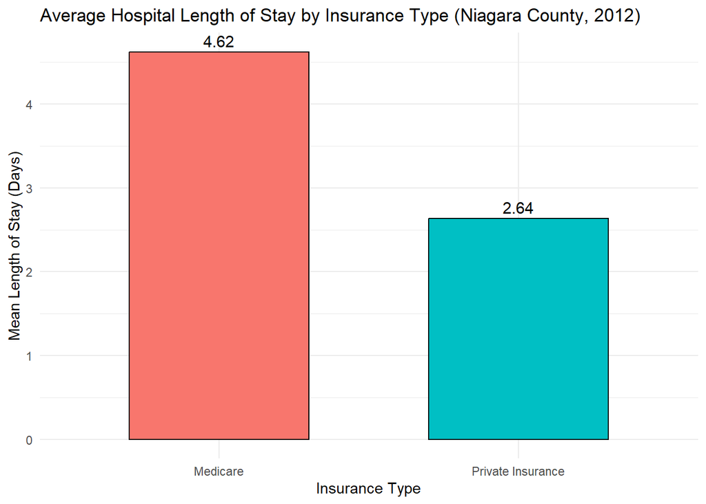

```r
# -----------------------------------------------------------
#cat("Step 8: Visualizing average hospital stays by insurance type\n")
ggplot(group_stats, aes(x = Insurance_Group, y = mean_LOS, fill = Insurance_Group)) +
  geom_bar(stat = "identity", width = 0.6, color = "black") +
  geom_text(aes(label = round(mean_LOS, 2)), vjust = -0.4, size = 4) +
  labs(
    title = "Average Hospital Length of Stay by Insurance Type (Niagara County, 2012)",
    x = "Insurance Type",
    y = "Mean Length of Stay (Days)"
  ) +
  theme_minimal() +
  theme(legend.position = "none")
```

## 4.2 SMART Question 2

**Can we analyze 2012 hospital records to quantify whether Medicaid patients’ total hospital costs were higher than patients with Private Insurance?**

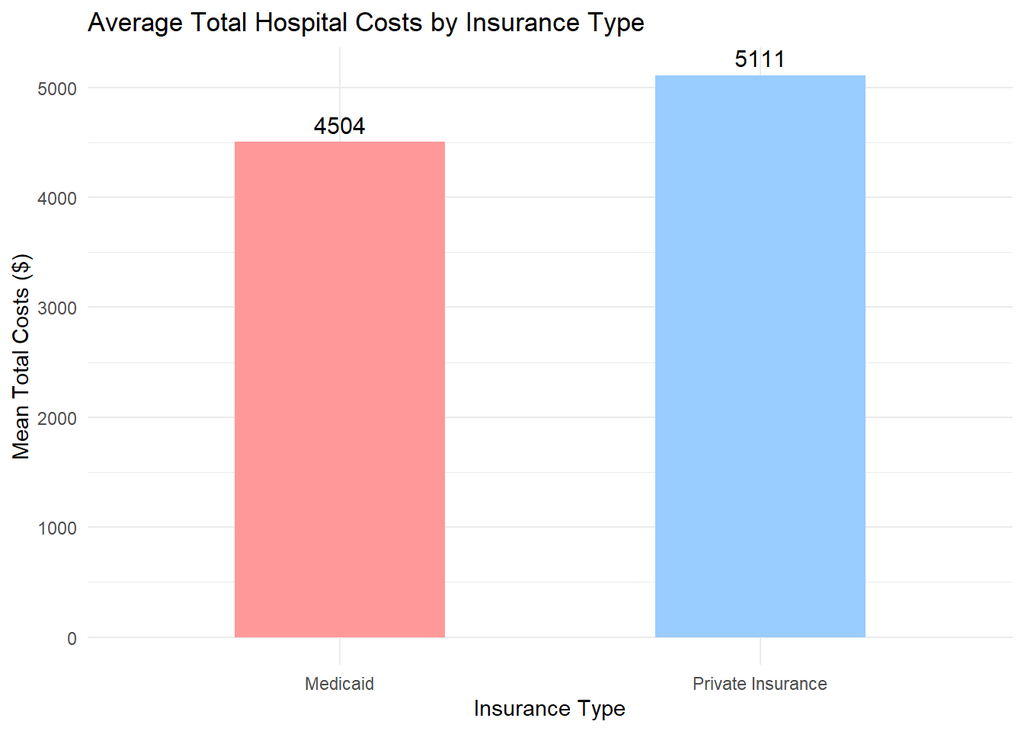

```r
# --- Bar plot: Mean Total Costs by Insurance Type ---
cost_means <- hospital_no_outliers %>%
  group_by(Insurance_Use) %>%
  summarise(mean_cost = mean(`Total.Costs`, na.rm = TRUE))


ggplot(cost_means, aes(x = Insurance_Use, y = mean_cost, fill = Insurance_Use)) +
  geom_bar(stat = "identity", width = 0.5) +
  geom_text(aes(label = round(mean_cost, 0)), vjust = -0.5, size = 4) +
  labs(
    title = "Average Total Hospital Costs by Insurance Type",
    x = "Insurance Type",
    y = "Mean Total Costs ($)"
  ) +
  scale_fill_manual(values = c("Medicaid" = "#FF9999", "Private Insurance" = "#99CCFF")) +
  theme_minimal() +
  theme(legend.position = "none")
```

```r
# Print result

means <- t_result$estimate
different_percent <- (means[1] - means[2]) / means[2] * 100
ci <- t_result$conf.int

if(different_percent>0){
  cat(" Medicaid patients' total hospital costs are approximately", round(abs(different_percent), 2), "% higher than Private Insurance.\n")
}else{
   cat("Medicaid patients' total hospital costs are approximately", round(abs(different_percent), 2), "% lower than Private Insurance.\n")
  cat("Medicaid patients had lower mean total hospital costs ($", round(means[1],2),
    ") than Private Insurance patients ($", round(means[2],2), "), approximately ",
    round(abs(different_percent),2), "% difference. ",
    "The difference was statistically significant (t = ", round(t_result$statistic,2),
    ", df = ", round(t_result$parameter,1), ", p < 0.001).\n", sep = "")
}
```

```
## Medicaid patients' total hospital costs are approximately 11.88 % lower than Private Insurance.
## Medicaid patients had lower mean total hospital costs ($4503.69) than Private Insurance patients ($5110.76), approximately 11.88% difference. The difference was statistically significant (t = -9.69, df = 8936.2, p < 0.001).
```

```r
cat("Extra part: Here we check the total_charge based on insurance types:")
```

```
## Extra part: Here we check the total_charge based on insurance types:
```

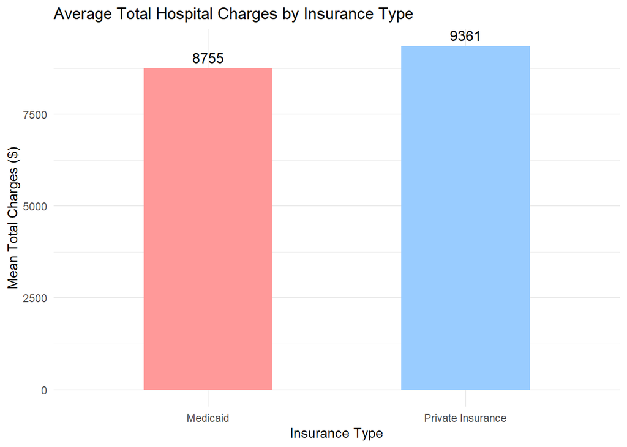

```r
# --- Bar plot: Mean Total Charges by Insurance Type ---
cost_means <- hospital_no_outliers %>%
  group_by(Insurance_Use) %>%
  summarise(mean_cost = mean(`Total.Charges`, na.rm = TRUE))


ggplot(cost_means, aes(x = Insurance_Use, y = mean_cost, fill = Insurance_Use)) +
  geom_bar(stat = "identity", width = 0.5) +
  geom_text(aes(label = round(mean_cost, 0)), vjust = -0.5, size = 4) +
  labs(
    title = "Average Total Hospital Charges by Insurance Type",
    x = "Insurance Type",
    y = "Mean Total Charges ($)"
  ) +
  scale_fill_manual(values = c("Medicaid" = "#FF9999", "Private Insurance" = "#99CCFF")) +
  theme_minimal() +
  theme(legend.position = "none")
```

```r
# Print result

means <- t_charge_result$estimate
different_percent <- (means[1] - means[2]) / means[2] * 100
ci <- t_charge_result$conf.int

if(different_percent>0){
  cat(" Medicaid patients' total hospital charges are approximately", round(abs(different_percent), 2), "% higher than Private Insurance.\n")
}else{
   cat("Medicaid patients' total hospital charges are approximately", round(abs(different_percent), 2), "% lower than Private Insurance.\n")
  cat("Medicaid patients had lower mean total hospital charges ($", round(means[1],2),
    ") than Private Insurance patients ($", round(means[2],2), "), approximately ",
    round(abs(different_percent),2), "% difference. ",
    "The difference was statistically significant (t = ", round(t_charge_result$statistic,2),
    ", df = ", round(t_charge_result$parameter,1), ", p < 0.001).\n", sep = "")
}
```

```
## Medicaid patients' total hospital charges are approximately 6.47 % lower than Private Insurance.
## Medicaid patients had lower mean total hospital charges ($8755.11) than Private Insurance patients ($9361.02), approximately 6.47% difference. The difference was statistically significant (t = -5.19, df = 9330.6, p < 0.001).
```

## 4.3 SMART Question 3

**Did elderly patients (70+) stay longer than patients aged 30–49 in 2012?**

```
## # A tibble: 2 × 2
##   Age.Group   mean_LOS
##   <chr>          <dbl>
## 1 30 to 49        5.28
## 2 70 or Older     5.55
##
## Elderly / 30–49 ratio = 1.05
```

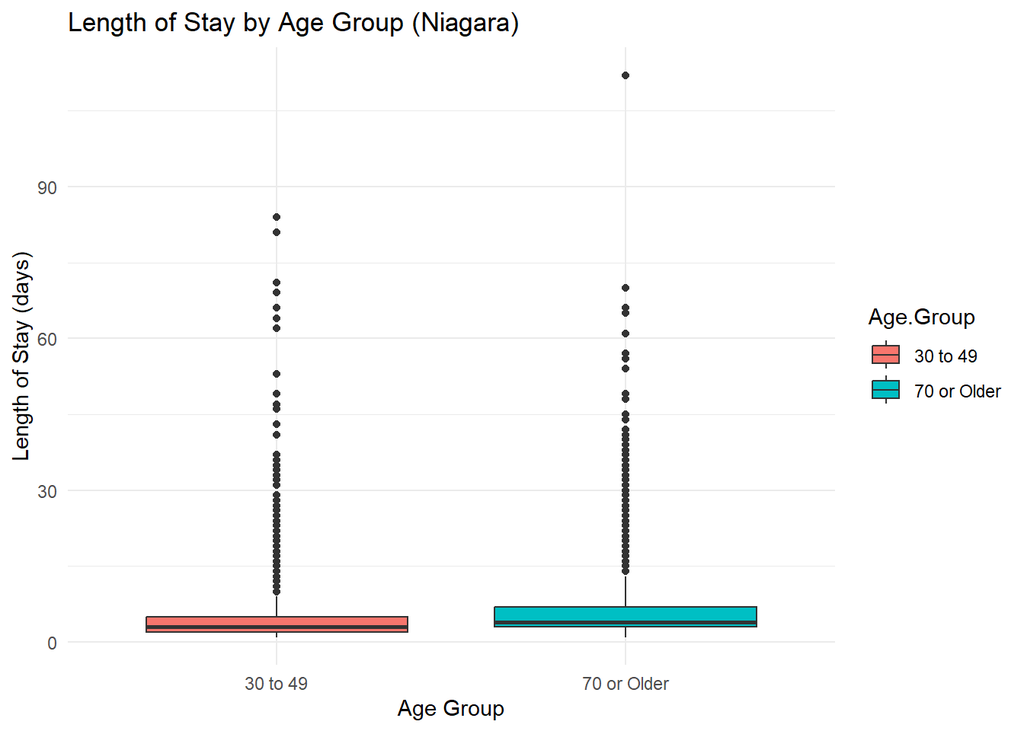

```r
 # Proceed only if two groups with valid data
if (length(unique(df_age$Age.Group)) == 2 &&
    all(sapply(split(df_age$Length.of.Stay, df_age$Age.Group), function(x) length(x) > 1))) {

  # Group means
  age_means <- df_age %>%
    group_by(Age.Group) %>%
    summarise(mean_LOS = mean(Length.of.Stay, na.rm = TRUE))
  print(age_means)

  # Calculate ratio
  ratio_age <- age_means$mean_LOS[grepl("70", age_means$Age.Group)] /
               age_means$mean_LOS[grepl("30", age_means$Age.Group)]
  cat("\nElderly / 30–49 ratio =", round(ratio_age, 2), "\n")

  # One-sided t-test (elderly > younger)
  #cat("\nWelch Two Sample t-test:\n")
  #print(t.test(Length.of.Stay ~ Age.Group, data = df_age, alternative = "greater"))

  # Boxplot
  ggplot(df_age, aes(x = Age.Group, y = Length.of.Stay, fill = Age.Group)) +
    geom_boxplot() +
    theme_minimal() +
    labs(title = "Length of Stay by Age Group (Niagara)",
         x = "Age Group", y = "Length of Stay (days)")

} else {
  cat("\n❌ Cannot run t-test. Check data integrity.\n")
}
```

```r
cat("p-value < 0.05\n",
    "Since the p-value is less than 0.05, we reject the null hypothesis.\n",
    "This means there is a statistically significant difference between the two group means.\n",
    "Elderly pationts(70+) stay signigicantly longer in the hospital compared to pationts aged 30-49.\n\n")
```

[output not shown]

[output not shown]

```
## p-value < 0.05
##  Since the p-value is less than 0.05, we reject the null hypothesis.
##  This means there is a statistically significant difference between the two group means.
##  Elderly pationts(70+) stay signigicantly longer in the hospital compared to pationts aged 30-49.
```

## 4.4 SMART Question 4

**Did emergency admissions result in longer hospital stays than elective ones in 2012?**

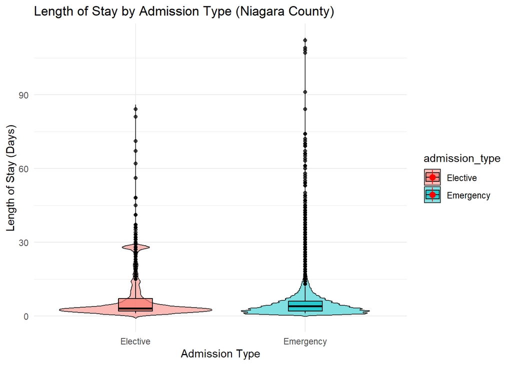

```r
# --- EDA Visuals ------------------------------------------------------------

# Violin + Box + CI

ggplot(dfq, aes(admission_type, los, fill = admission_type)) +
geom_violin(trim = FALSE, alpha = 0.5) +
geom_boxplot(width = 0.2, alpha = 0.7, color = "black") +
stat_summary(fun.data = mean_cl_normal, geom = "pointrange", color = "red") +
labs(title = "Length of Stay by Admission Type (Niagara County)",
x = "Admission Type", y = "Length of Stay (Days)") +
theme_minimal()
```

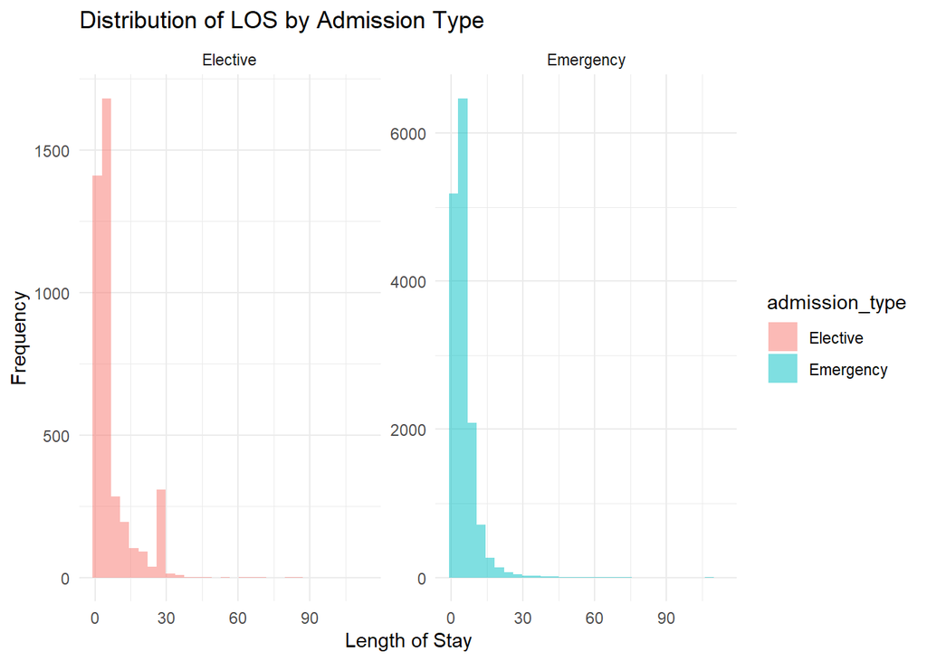

```r
# Histogram

ggplot(dfq, aes(los, fill = admission_type)) +
geom_histogram(position = "identity", alpha = 0.5, bins = 30) +
facet_wrap(~ admission_type, scales = "free_y") +
theme_minimal() +
labs(title = "Distribution of LOS by Admission Type",
x = "Length of Stay", y = "Frequency")
```

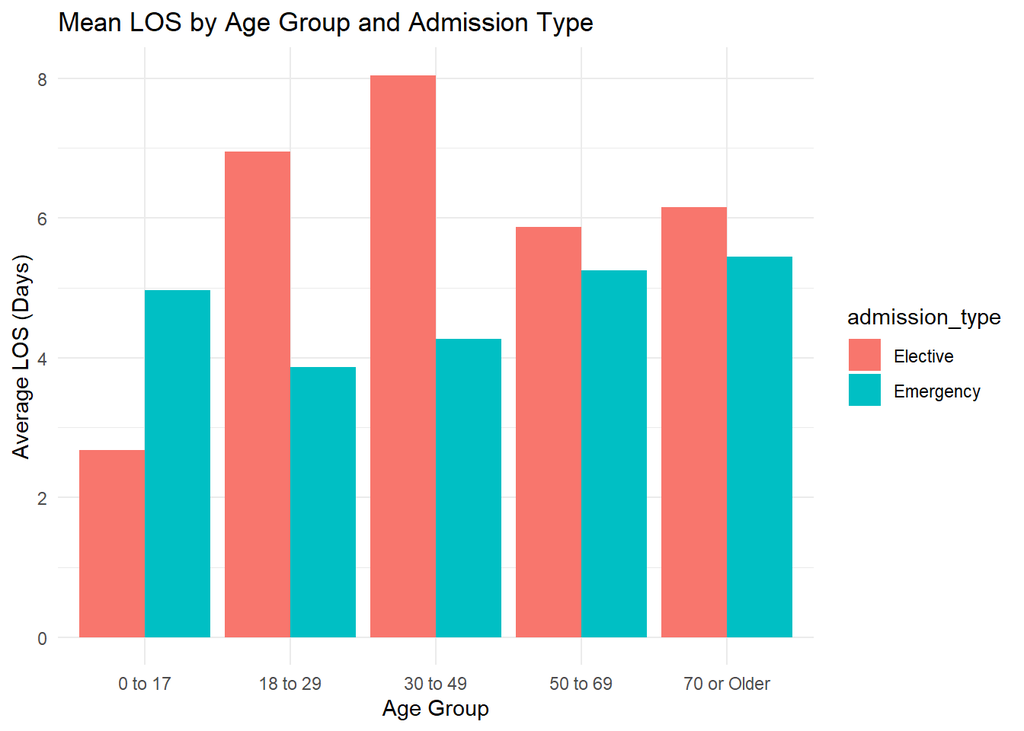

```r
# Mean LOS by Age Group

dfq %>%
group_by(age_group, admission_type) %>%
summarise(mean_los = mean(los, na.rm = TRUE)) %>%
ggplot(aes(age_group, mean_los, fill = admission_type)) +
geom_col(position = "dodge") +
labs(title = "Mean LOS by Age Group and Admission Type",
x = "Age Group", y = "Average LOS (Days)") +
theme_minimal()
```

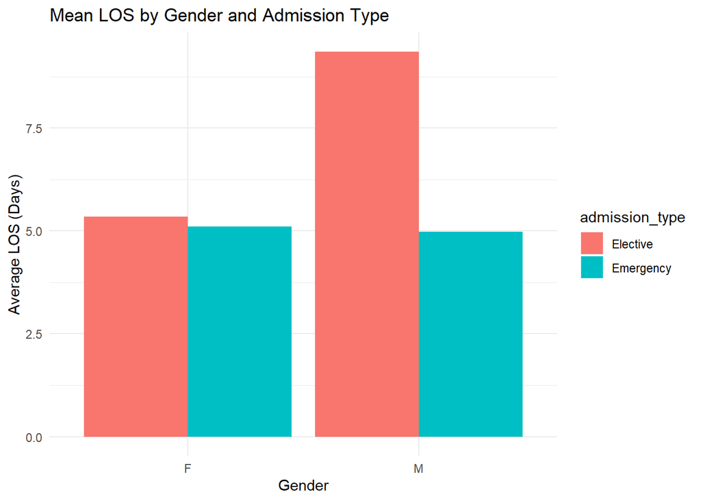

```r
# Mean LOS by Gender

dfq %>%
group_by(gender, admission_type) %>%
summarise(mean_los = mean(los, na.rm = TRUE)) %>%
ggplot(aes(gender, mean_los, fill = admission_type)) +
geom_col(position = "dodge") +
labs(title = "Mean LOS by Gender and Admission Type",
x = "Gender", y = "Average LOS (Days)") +
theme_minimal()
```

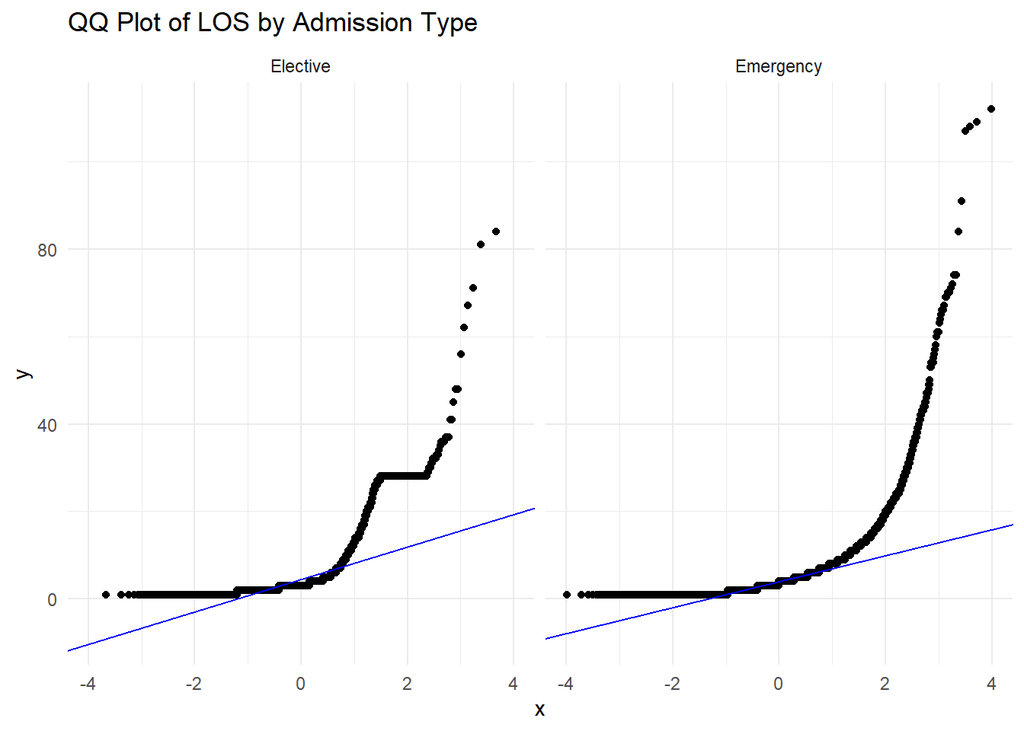

```r
# --- Assumption Checks ------------------------------------------------------



ggplot(dfq, aes(sample = los)) +
stat_qq() + stat_qq_line(color = "blue") +
facet_wrap(~ admission_type) +
theme_minimal() +
labs(title = "QQ Plot of LOS by Admission Type")
```

```r
# --- final takeway --------------------------------------------------------------


cat("
• Emergency patients stay significantly SHORTER than elective patients.
• Observed mean ratio (Emergency/Elective) ≈ ", round(mean_emergency/mean_elective, 3), ".
• Welch t-test: p-value from t_res = ", signif(t_res$p.value, 3), ".
• Effect size is small-to-moderate (report the actual Cohen's d below).
• Implication: elective (often surgical) cases drive longer LOS; plan capacity accordingly.
")
```

```
##
## • Emergency patients stay significantly SHORTER than elective patients.
## • Observed mean ratio (Emergency/Elective) ≈  0.751 .
## • Welch t-test: p-value from t_res =  6.2e-34 .
## • Effect size is small-to-moderate (report the actual Cohen's d below).
## • Implication: elective (often surgical) cases drive longer LOS; plan capacity accordingly.
```

# 5 Results

## 5.2 SMART Question2: Medicaid vs Private (Costs & Charges)

- Total Costs ≈ 11.88% lower and Total Charges ≈ 6.47% lower for Medicaid.
- *t* = –9.69 and –5.19; *p* < 0.001 for both of them→ **Significant**, but **opposite to hypothesis** (Medicaid lower). → Reject H₁, support H₀.
- Medicaid total costs and total charges are lower than Private, opposite to the initial hypothesis.

## 5.4 SMART Question4: Elective vs Emergency (LOS)

- Levene *F* = 246.15, *p* < 2.2×10⁻¹⁶ → unequal variances.
- Welch *t* = 12.23, *p* < 2.2×10⁻¹⁶; Mean LOS 6.724 (Elective) vs 5.049 (Emergency); 95% CI [1.406, 1.943]; Cohen’s d ≈ 0.26 (small–moderate).
- Log(LOS) confirmed significance ( LOS test t = 8.20, p < 3×10⁻¹⁶ confirmed significance).
- OLS model (LOS ~ Admission Type + Age + Gender): Emergency Estimate ≈ –1.90 days (*p* < 2×10⁻¹⁶). → All analytic layers yielded consistent direction and statistical significance.

# 6 Conclusion & Discussion

# 7 Project Workflow Summary (structured outline)

1. Data acquisition & initial inspection
2. Data cleaning and variable derivation (document every transformation)
3. Exploratory Data Analysis (visual + summary statistics)
4. Hypothesis specification (SMART questions)
5. Statistical testing / modeling (with assumption checks)
6. Interpretation and robustness checks
7. Reporting: visualizations, tables for each SMART question, and final HTML

# 8 Reference

Dataset Link: https://health.data.ny.gov/Health/Hospital-Inpatient-Discharges-SPARCS-De-Identified/u4ud-w55t/about_data